# OpenSAFELY COVID-19 Vaccine Coverage Snapshot

OpenSAFELY is a secure analytics platform for electronic patient records built on behalf of NHS England to deliver urgent academic and operational research during the pandemic.

This snapshot of vaccine coverage is an extension of our [previous weekly reports](https://reports.opensafely.org/reports/vaccine-coverage-thirdbooster-doses/) on COVID-19 vaccination uptake in England. The snapshot includes data from the 40% of general practices that use TPP electronic health record software. The data requires careful interpretation and there are a number of caveats. Please read the full detail about our methods and discussion of our earlier results in our [peer-reviewed publication in the British Journal of General Practice](https://bjgp.org/content/72/714/e51).

The full analytic methods behind the latest results in this report are available [here](https://github.com/opensafely/vaccine-counts).

### Contents

- Overview of coverage snapshot - 01 September 2023
- Summary charts
  - Vaccination history by age
  - Vaccination history by age and ethnicity
  - Vaccination history by age and index of multiple deprivation
- Summary tables
  - Vaccination history by age
  - 75y+ population: Vaccination history by demographic and clinical subgroups
  - 65-74y population: Vaccination history by demographic and clinical subgroups
  - 50-64y population: Vaccination history by demographic and clinical subgroups
  - 18-49y population: Vaccination history by demographic and clinical subgroups
- UK vaccine implementation in adults

### Overview of coverage snapshot - 01 September 2023

- This report summarises the vaccination history of adults in England as of 01 September 2023 - immediately prior to the Autumn 2023 COVID-19 vaccine booster campaign. A summary of COVID-19 vaccine implementation for adults in the UK is given below.
- Age is calculated at 01 September 2023. Age groups (18-49, 50-64, 65-74, and 75+) reflect the eligibility cut-offs used over successive booster campaigns in the UK, as described below.
- Clinical subgroups are defined using codelists described in our peer-reviewed publication in the Lancet Public Health.
- Index of multiple deprivation is a measure of relative deprivation based on the local area in which a patient lives.
- We do not distinguish between vaccine products or manufacturers (Oxford/AstraZeneca, Pfizer/BioNTech, or Moderna).
- For calculation of median time since last dose, unvaccinated individuals were assigned a value of 36 months (exceeding the maximum possible value among vaccinated individuals).
- Patient counts are rounded to the nearest 7. Rounded counts of <=7 are redacted.

### Summary charts

#### Vaccination history by age

**Show/hide more details**

*See summary tables for additional data.*

*In the column on the right, time since last dose is displayed using density plots, which show the relative concentration of values over a given range. In this instance, the height of the lines represents the proportion of individuals, and peaks reflect the timing of different booster campaigns.*

*Specifically, peaks at 2-6 months reflect individuals most recently vaccinated during the Spring 2023 booster campaign, peaks at 9-12 months reflect individuals most recently vaccinated during the Autumn 2022 campaign, and peaks at 18-24 months reflect individuals most recently vaccinated during the Autumn 2021 booster campaign. Further details on the timing and eligibility for each campaign can be found below.*

*In addition to these density plots, the average (median) time since last dose for each subgroup is provided in the summary tables.*

*Abbreviation: Unvax = unvaccinated.*

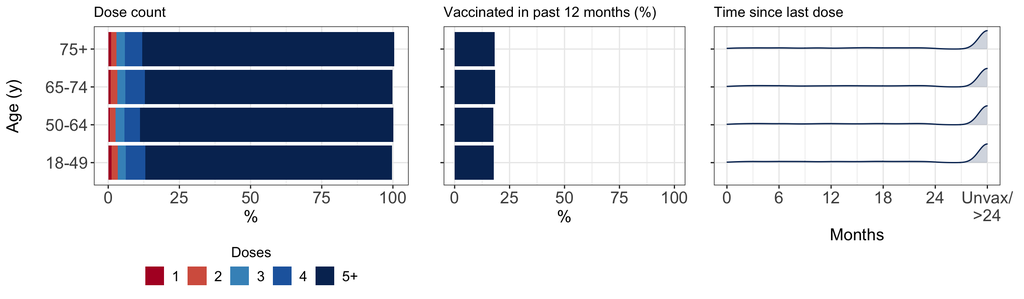

#### Vaccination history by age and ethnicity

**Show/hide more details**

*See summary tables for additional data, including vaccination history according to more narrowly defined ethnic groups.*

*In the column on the right, time since last dose is displayed using density plots, which show the relative concentration of values over a given range. In this instance, the height of the lines represents the proportion of individuals, and peaks reflect the timing of different booster campaigns.*

*Specifically, peaks at 2-6 months reflect individuals most recently vaccinated during the Spring 2023 booster campaign, peaks at 9-12 months reflect individuals most recently vaccinated during the Autumn 2022 campaign, and peaks at 18-24 months reflect individuals most recently vaccinated during the Autumn 2021 booster campaign. Further details on the timing and eligibility for each campaign can be found below.*

*In addition to these density plots, the average (median) time since last dose for each subgroup is provided in the summary tables.*

*Abbreviation: Unvax = unvaccinated.*

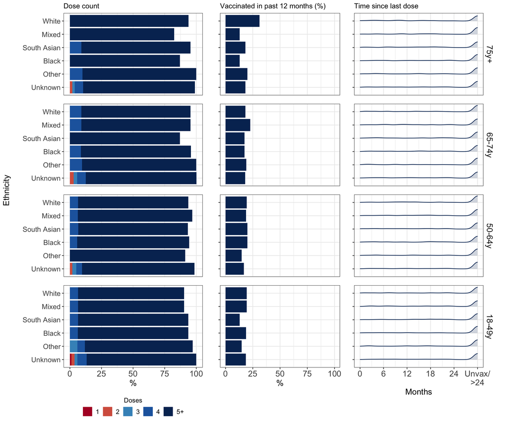

#### Vaccination history by age and index of multiple deprivation

**Show/hide more details**

*See summary tables for additional data.*

*In the column on the right, time since last dose is displayed using density plots, which show the relative concentration of values over a given range. In this instance, the height of the lines represents the proportion of individuals, and peaks reflect the timing of different booster campaigns.*

*Specifically, peaks at 2-6 months reflect individuals most recently vaccinated during the Spring 2023 booster campaign, peaks at 9-12 months reflect individuals most recently vaccinated during the Autumn 2022 campaign, and peaks at 18-24 months reflect individuals most recently vaccinated during the Autumn 2021 booster campaign. Further details on the timing and eligibility for each campaign can be found below.*

*In addition to these density plots, the average (median) time since last dose for each subgroup is provided in the summary tables.*

*Abbreviation: Unvax = unvaccinated.*

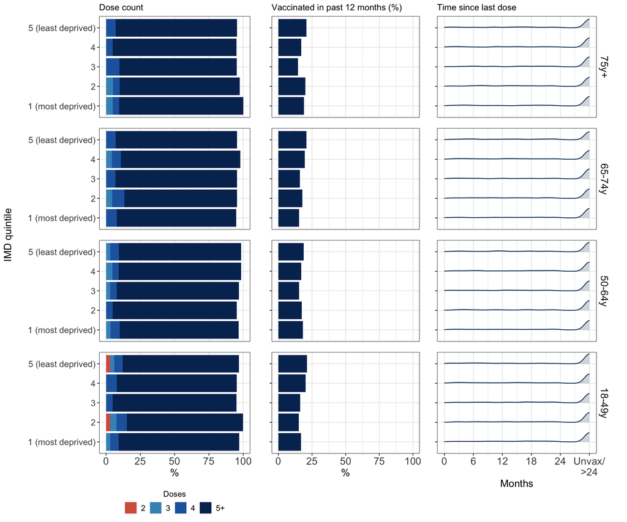

### Summary tables

#### Vaccination history by age

| Age group | N | Dose count 0 | Dose count 1 | Dose count 2 | Dose count 3 | Dose count 4 | Dose count 5+ | Dose count, median (IQR) | Vaccinated in past 12 months, n (%) | Vaccinated in past 24 months, n (%) | Time in months since last dose, median (IQR) |  |  |  |  |
| --- | --- | --- | --- | --- | --- | --- | --- | --- | --- | --- | --- | --- | --- | --- | --- |
| 75+ | 1,456 | 10,000 (11.1%) | 14 (1%) | 28 (1.9%) | 42 (2.9%) | 91 (6.2%) | 1,288 (88.5%) |  |  |  |  | 6 (6-7) | 266 (18.3%) | 546 (37.5%) | 31.8 (16.3-36) |
| 65-74 | 1,512 | 10,000 (11.1%) | 14 (0.9%) | 35 (2.3%) | 42 (2.8%) | 105 (6.9%) | 1,316 (87%) | 7 (6-7) | 280 (18.5%) | 567 (37.5%) | 32.9 (16.5-36) |  |  |  |  |
| 50-64 | 2,219 | 10,000 (11.1%) | 14 (0.6%) | 42 (1.9%) | 70 (3.2%) | 119 (5.4%) | 1,974 (89%) | 6 (5-7) | 392 (17.7%) | 791 (35.6%) | 32.9 (17-36) |  |  |  |  |
| 18-49 | 2,268 | 10,000 (11.1%) | 28 (1.2%) | 49 (2.2%) | 63 (2.8%) | 154 (6.8%) | 1,967 (86.7%) | 6 (5-7) | 406 (17.9%) | 833 (36.7%) | 32.7 (17-36) |  |  |  |  |

*Abbreviation: IQR = interquartile range.*

#### 75y+ population: Vaccination history by demographic and clinical subgroups

**Show/hide table**

| Level | N | Dose count 0 | Dose count 1 | Dose count 2 | Dose count 3 | Dose count 4 | Dose count 5+ | Dose count, median (IQR) | Vaccinated in past 12 months, n (%) | Vaccinated in past 24 months, n (%) | Time in months since last dose, median (IQR) |  |  |  |  |
| --- | --- | --- | --- | --- | --- | --- | --- | --- | --- | --- | --- | --- | --- | --- | --- |
| Sex |  |  |  |  |  |  |  |  |  |  |  |  |  |  |  |
| Female | 749 | 10,000 (11.1%) | 10,000 (11.1%) | 10,000 (11.1%) | 28 (3.7%) | 42 (5.6%) | 658 (87.9%) |  |  |  |  | 7 (6-7) | 133 (17.8%) | 280 (37.4%) | 31.5 (16.6-36) |
| Male | 714 | 10,000 (11.1%) | 10,000 (11.1%) | 14 (2%) | 14 (2%) | 49 (6.9%) | 623 (87.3%) | 6 (5-7) | 133 (18.6%) | 266 (37.3%) | 32.2 (16.3-36) |  |  |  |  |
| Ethnicity (broad categories) |  |  |  |  |  |  |  |  |  |  |  |  |  |  |  |
| White | 112 | 10,000 (11.1%) | 10,000 (11.1%) | 10,000 (11.1%) | 10,000 (11.1%) | 10,000 (11.1%) | 105 (93.8%) | 7 (6-7) | 35 (31.2%) | 49 (43.8%) | 26.7 (10.1-36) |  |  |  |  |
| Mixed | 161 | 10,000 (11.1%) | 10,000 (11.1%) | 10,000 (11.1%) | 10,000 (11.1%) | 10,000 (11.1%) | 133 (82.6%) | 7 (6-7) | 21 (13%) | 49 (30.4%) | 36 (18.6-36) |  |  |  |  |
| South Asian | 154 | 10,000 (11.1%) | 10,000 (11.1%) | 10,000 (11.1%) | 10,000 (11.1%) | 14 (9.1%) | 133 (86.4%) | 7 (5-7) | 28 (18.2%) | 63 (40.9%) | 30.4 (15.5-36) |  |  |  |  |
| Black | 161 | 10,000 (11.1%) | 10,000 (11.1%) | 10,000 (11.1%) | 10,000 (11.1%) | 10,000 (11.1%) | 140 (87%) | 6 (5-7) | 21 (13%) | 56 (34.8%) | 32.8 (19.5-36) |  |  |  |  |
| Other | 140 | 10,000 (11.1%) | 10,000 (11.1%) | 10,000 (11.1%) | 10,000 (11.1%) | 14 (10%) | 126 (90%) | 6 (6-7) | 28 (20%) | 49 (35%) | 36 (16.2-36) |  |  |  |  |
| Unknown | 728 | 10,000 (11.1%) | 10,000 (11.1%) | 14 (1.9%) | 14 (1.9%) | 49 (6.7%) | 644 (88.5%) | 7 (6-7) | 133 (18.3%) | 280 (38.5%) | 31.5 (16.3-36) |  |  |  |  |
| Ethnicity (narrow categories) |  |  |  |  |  |  |  |  |  |  |  |  |  |  |  |
| British or Mixed British | 49 | 10,000 (11.1%) | 10,000 (11.1%) | 10,000 (11.1%) | 10,000 (11.1%) | 10,000 (11.1%) | 10,000 (11.1%) | 11.1 (10.1-12.1) | 10,000 (11.1%) | 10,000 (11.1%) | 11.1 (10.1-12.1) |  |  |  |  |
| Irish | 42 | 10,000 (11.1%) | 10,000 (11.1%) | 10,000 (11.1%) | 10,000 (11.1%) | 10,000 (11.1%) | 10,000 (11.1%) | 11.1 (10.1-12.1) | 10,000 (11.1%) | 10,000 (11.1%) | 11.1 (10.1-12.1) |  |  |  |  |
| Other White | 49 | 10,000 (11.1%) | 10,000 (11.1%) | 10,000 (11.1%) | 10,000 (11.1%) | 10,000 (11.1%) | 10,000 (11.1%) | 11.1 (10.1-12.1) | 10,000 (11.1%) | 10,000 (11.1%) | 11.1 (10.1-12.1) |  |  |  |  |
| White + Black Caribbean | 49 | 10,000 (11.1%) | 10,000 (11.1%) | 10,000 (11.1%) | 10,000 (11.1%) | 10,000 (11.1%) | 10,000 (11.1%) | 11.1 (10.1-12.1) | 10,000 (11.1%) | 10,000 (11.1%) | 11.1 (10.1-12.1) |  |  |  |  |
| White + Black African | 49 | 10,000 (11.1%) | 10,000 (11.1%) | 10,000 (11.1%) | 10,000 (11.1%) | 10,000 (11.1%) | 10,000 (11.1%) | 11.1 (10.1-12.1) | 10,000 (11.1%) | 10,000 (11.1%) | 11.1 (10.1-12.1) |  |  |  |  |
| White + Asian | 49 | 10,000 (11.1%) | 10,000 (11.1%) | 10,000 (11.1%) | 10,000 (11.1%) | 10,000 (11.1%) | 10,000 (11.1%) | 11.1 (10.1-12.1) | 10,000 (11.1%) | 10,000 (11.1%) | 11.1 (10.1-12.1) |  |  |  |  |
| Other mixed | 35 | 10,000 (11.1%) | 10,000 (11.1%) | 10,000 (11.1%) | 10,000 (11.1%) | 10,000 (11.1%) | 10,000 (11.1%) | 11.1 (10.1-12.1) | 10,000 (11.1%) | 10,000 (11.1%) | 11.1 (10.1-12.1) |  |  |  |  |
| Indian or British Indian | 42 | 10,000 (11.1%) | 10,000 (11.1%) | 10,000 (11.1%) | 10,000 (11.1%) | 10,000 (11.1%) | 10,000 (11.1%) | 11.1 (10.1-12.1) | 10,000 (11.1%) | 10,000 (11.1%) | 11.1 (10.1-12.1) |  |  |  |  |
| Pakistani or British Pakistani | 42 | 10,000 (11.1%) | 10,000 (11.1%) | 10,000 (11.1%) | 10,000 (11.1%) | 10,000 (11.1%) | 10,000 (11.1%) | 11.1 (10.1-12.1) | 10,000 (11.1%) | 10,000 (11.1%) | 11.1 (10.1-12.1) |  |  |  |  |
| Bangladeshi or British Bangladeshi | 35 | 10,000 (11.1%) | 10,000 (11.1%) | 10,000 (11.1%) | 10,000 (11.1%) | 10,000 (11.1%) | 10,000 (11.1%) | 11.1 (10.1-12.1) | 10,000 (11.1%) | 10,000 (11.1%) | 11.1 (10.1-12.1) |  |  |  |  |
| Other Asian | 42 | 10,000 (11.1%) | 10,000 (11.1%) | 10,000 (11.1%) | 10,000 (11.1%) | 10,000 (11.1%) | 10,000 (11.1%) | 11.1 (10.1-12.1) | 10,000 (11.1%) | 10,000 (11.1%) | 11.1 (10.1-12.1) |  |  |  |  |
| Caribbean | 42 | 10,000 (11.1%) | 10,000 (11.1%) | 10,000 (11.1%) | 10,000 (11.1%) | 10,000 (11.1%) | 10,000 (11.1%) | 11.1 (10.1-12.1) | 10,000 (11.1%) | 10,000 (11.1%) | 11.1 (10.1-12.1) |  |  |  |  |
| African | 56 | 10,000 (11.1%) | 10,000 (11.1%) | 10,000 (11.1%) | 10,000 (11.1%) | 10,000 (11.1%) | 10,000 (11.1%) | 11.1 (10.1-12.1) | 10,000 (11.1%) | 10,000 (11.1%) | 11.1 (10.1-12.1) |  |  |  |  |
| Other Black | 56 | 10,000 (11.1%) | 10,000 (11.1%) | 10,000 (11.1%) | 10,000 (11.1%) | 10,000 (11.1%) | 10,000 (11.1%) | 11.1 (10.1-12.1) | 10,000 (11.1%) | 10,000 (11.1%) | 11.1 (10.1-12.1) |  |  |  |  |
| Chinese | 49 | 10,000 (11.1%) | 10,000 (11.1%) | 10,000 (11.1%) | 10,000 (11.1%) | 10,000 (11.1%) | 10,000 (11.1%) | 11.1 (10.1-12.1) | 10,000 (11.1%) | 10,000 (11.1%) | 11.1 (10.1-12.1) |  |  |  |  |
| Other | 35 | 10,000 (11.1%) | 10,000 (11.1%) | 10,000 (11.1%) | 10,000 (11.1%) | 10,000 (11.1%) | 10,000 (11.1%) | 11.1 (10.1-12.1) | 10,000 (11.1%) | 10,000 (11.1%) | 11.1 (10.1-12.1) |  |  |  |  |
| Unknown | 742 | 10,000 (11.1%) | 10,000 (11.1%) | 14 (1.9%) | 21 (2.8%) | 42 (5.7%) | 658 (88.7%) | 7 (6-7) | 140 (18.9%) | 280 (37.7%) | 31.5 (15.9-36) |  |  |  |  |
| IMD quintile |  |  |  |  |  |  |  |  |  |  |  |  |  |  |  |
| 5 (least deprived) | 301 | 10,000 (11.1%) | 10,000 (11.1%) | 10,000 (11.1%) | 10,000 (11.1%) | 21 (7%) | 266 (88.4%) | 6 (6-7) | 63 (20.9%) | 126 (41.9%) | 30.6 (15.1-36) |  |  |  |  |

[output cut: 75 more lines]

*Abbreviations: CKD = chronic kidney disease; IMD = index of multiple deprivation; IQR = interquartile range; RRT = renal replacement therapy.*

#### 65-74y population: Vaccination history by demographic and clinical subgroups

**Show/hide table**

| Level | N | Dose count 0 | Dose count 1 | Dose count 2 | Dose count 3 | Dose count 4 | Dose count 5+ | Dose count, median (IQR) | Vaccinated in past 12 months, n (%) | Vaccinated in past 24 months, n (%) | Time in months since last dose, median (IQR) |  |  |  |  |
| --- | --- | --- | --- | --- | --- | --- | --- | --- | --- | --- | --- | --- | --- | --- | --- |
| Sex |  |  |  |  |  |  |  |  |  |  |  |  |  |  |  |
| Female | 777 | 10,000 (11.1%) | 14 (1.8%) | 14 (1.8%) | 21 (2.7%) | 56 (7.2%) | 672 (86.5%) |  |  |  |  | 6 (5-7) | 140 (18%) | 280 (36%) | 36 (16.6-36) |
| Male | 735 | 10,000 (11.1%) | 10,000 (11.1%) | 14 (1.9%) | 21 (2.9%) | 49 (6.7%) | 644 (87.6%) | 7 (6-7) | 140 (19%) | 287 (39%) | 32 (16.6-36) |  |  |  |  |
| Ethnicity (broad categories) |  |  |  |  |  |  |  |  |  |  |  |  |  |  |  |
| White | 154 | 10,000 (11.1%) | 10,000 (11.1%) | 10,000 (11.1%) | 10,000 (11.1%) | 14 (9.1%) | 133 (86.4%) | 7 (6-7) | 28 (18.2%) | 56 (36.4%) | 32.8 (15.8-36) |  |  |  |  |
| Mixed | 154 | 10,000 (11.1%) | 10,000 (11.1%) | 10,000 (11.1%) | 10,000 (11.1%) | 14 (9.1%) | 133 (86.4%) | 7 (5-7) | 35 (22.7%) | 56 (36.4%) | 31.8 (15-36) |  |  |  |  |
| South Asian | 161 | 10,000 (11.1%) | 10,000 (11.1%) | 10,000 (11.1%) | 10,000 (11.1%) | 10,000 (11.1%) | 140 (87%) | 7 (5-7) | 28 (17.4%) | 56 (34.8%) | 36 (19-36) |  |  |  |  |
| Black | 161 | 10,000 (11.1%) | 10,000 (11.1%) | 10,000 (11.1%) | 10,000 (11.1%) | 14 (8.7%) | 140 (87%) | 6 (5-7) | 28 (17.4%) | 63 (39.1%) | 36 (17.1-36) |  |  |  |  |
| Other | 147 | 10,000 (11.1%) | 10,000 (11.1%) | 10,000 (11.1%) | 10,000 (11.1%) | 14 (9.5%) | 133 (90.5%) | 6.5 (5-7) | 28 (19%) | 49 (33.3%) | 36 (17.8-36) |  |  |  |  |
| Unknown | 735 | 10,000 (11.1%) | 10,000 (11.1%) | 21 (2.9%) | 21 (2.9%) | 49 (6.7%) | 644 (87.6%) | 6 (6-7) | 133 (18.1%) | 280 (38.1%) | 32.3 (15.9-36) |  |  |  |  |
| Ethnicity (narrow categories) |  |  |  |  |  |  |  |  |  |  |  |  |  |  |  |
| British or Mixed British | 49 | 10,000 (11.1%) | 10,000 (11.1%) | 10,000 (11.1%) | 10,000 (11.1%) | 10,000 (11.1%) | 10,000 (11.1%) | 11.1 (10.1-12.1) | 10,000 (11.1%) | 10,000 (11.1%) | 11.1 (10.1-12.1) |  |  |  |  |
| Irish | 56 | 10,000 (11.1%) | 10,000 (11.1%) | 10,000 (11.1%) | 10,000 (11.1%) | 10,000 (11.1%) | 10,000 (11.1%) | 11.1 (10.1-12.1) | 10,000 (11.1%) | 10,000 (11.1%) | 11.1 (10.1-12.1) |  |  |  |  |
| Other White | 35 | 10,000 (11.1%) | 10,000 (11.1%) | 10,000 (11.1%) | 10,000 (11.1%) | 10,000 (11.1%) | 10,000 (11.1%) | 11.1 (10.1-12.1) | 10,000 (11.1%) | 10,000 (11.1%) | 11.1 (10.1-12.1) |  |  |  |  |
| White + Black Caribbean | 42 | 10,000 (11.1%) | 10,000 (11.1%) | 10,000 (11.1%) | 10,000 (11.1%) | 10,000 (11.1%) | 10,000 (11.1%) | 11.1 (10.1-12.1) | 10,000 (11.1%) | 10,000 (11.1%) | 11.1 (10.1-12.1) |  |  |  |  |
| White + Black African | 56 | 10,000 (11.1%) | 10,000 (11.1%) | 10,000 (11.1%) | 10,000 (11.1%) | 10,000 (11.1%) | 10,000 (11.1%) | 11.1 (10.1-12.1) | 10,000 (11.1%) | 10,000 (11.1%) | 11.1 (10.1-12.1) |  |  |  |  |
| White + Asian | 42 | 10,000 (11.1%) | 10,000 (11.1%) | 10,000 (11.1%) | 10,000 (11.1%) | 10,000 (11.1%) | 10,000 (11.1%) | 11.1 (10.1-12.1) | 10,000 (11.1%) | 10,000 (11.1%) | 11.1 (10.1-12.1) |  |  |  |  |
| Other mixed | 49 | 10,000 (11.1%) | 10,000 (11.1%) | 10,000 (11.1%) | 10,000 (11.1%) | 10,000 (11.1%) | 10,000 (11.1%) | 11.1 (10.1-12.1) | 10,000 (11.1%) | 10,000 (11.1%) | 11.1 (10.1-12.1) |  |  |  |  |
| Indian or British Indian | 42 | 10,000 (11.1%) | 10,000 (11.1%) | 10,000 (11.1%) | 10,000 (11.1%) | 10,000 (11.1%) | 10,000 (11.1%) | 11.1 (10.1-12.1) | 10,000 (11.1%) | 10,000 (11.1%) | 11.1 (10.1-12.1) |  |  |  |  |
| Pakistani or British Pakistani | 56 | 10,000 (11.1%) | 10,000 (11.1%) | 10,000 (11.1%) | 10,000 (11.1%) | 10,000 (11.1%) | 10,000 (11.1%) | 11.1 (10.1-12.1) | 10,000 (11.1%) | 10,000 (11.1%) | 11.1 (10.1-12.1) |  |  |  |  |
| Bangladeshi or British Bangladeshi | 63 | 10,000 (11.1%) | 10,000 (11.1%) | 10,000 (11.1%) | 10,000 (11.1%) | 10,000 (11.1%) | 10,000 (11.1%) | 11.1 (10.1-12.1) | 10,000 (11.1%) | 10,000 (11.1%) | 11.1 (10.1-12.1) |  |  |  |  |
| Other Asian | 63 | 10,000 (11.1%) | 10,000 (11.1%) | 10,000 (11.1%) | 10,000 (11.1%) | 10,000 (11.1%) | 10,000 (11.1%) | 11.1 (10.1-12.1) | 10,000 (11.1%) | 10,000 (11.1%) | 11.1 (10.1-12.1) |  |  |  |  |
| Caribbean | 49 | 10,000 (11.1%) | 10,000 (11.1%) | 10,000 (11.1%) | 10,000 (11.1%) | 10,000 (11.1%) | 10,000 (11.1%) | 11.1 (10.1-12.1) | 10,000 (11.1%) | 10,000 (11.1%) | 11.1 (10.1-12.1) |  |  |  |  |
| African | 49 | 10,000 (11.1%) | 10,000 (11.1%) | 10,000 (11.1%) | 10,000 (11.1%) | 10,000 (11.1%) | 10,000 (11.1%) | 11.1 (10.1-12.1) | 10,000 (11.1%) | 10,000 (11.1%) | 11.1 (10.1-12.1) |  |  |  |  |
| Other Black | 49 | 10,000 (11.1%) | 10,000 (11.1%) | 10,000 (11.1%) | 10,000 (11.1%) | 10,000 (11.1%) | 10,000 (11.1%) | 11.1 (10.1-12.1) | 10,000 (11.1%) | 10,000 (11.1%) | 11.1 (10.1-12.1) |  |  |  |  |
| Chinese | 49 | 10,000 (11.1%) | 10,000 (11.1%) | 10,000 (11.1%) | 10,000 (11.1%) | 10,000 (11.1%) | 10,000 (11.1%) | 11.1 (10.1-12.1) | 10,000 (11.1%) | 10,000 (11.1%) | 11.1 (10.1-12.1) |  |  |  |  |
| Other | 42 | 10,000 (11.1%) | 10,000 (11.1%) | 10,000 (11.1%) | 10,000 (11.1%) | 10,000 (11.1%) | 10,000 (11.1%) | 11.1 (10.1-12.1) | 10,000 (11.1%) | 10,000 (11.1%) | 11.1 (10.1-12.1) |  |  |  |  |
| Unknown | 735 | 10,000 (11.1%) | 10,000 (11.1%) | 14 (1.9%) | 21 (2.9%) | 49 (6.7%) | 644 (87.6%) | 7 (6-7) | 133 (18.1%) | 273 (37.1%) | 32.2 (17.3-36) |  |  |  |  |
| IMD quintile |  |  |  |  |  |  |  |  |  |  |  |  |  |  |  |
| 5 (least deprived) | 301 | 10,000 (11.1%) | 10,000 (11.1%) | 10,000 (11.1%) | 10,000 (11.1%) | 21 (7%) | 266 (88.4%) | 6 (6-7) | 63 (20.9%) | 133 (44.2%) | 26.8 (13.8-36) |  |  |  |  |

[output cut: 75 more lines]

*Abbreviations: CKD = chronic kidney disease; IMD = index of multiple deprivation; IQR = interquartile range; RRT = renal replacement therapy.*

#### 50-64y population: Vaccination history by demographic and clinical subgroups

**Show/hide table**

| Level | N | Dose count 0 | Dose count 1 | Dose count 2 | Dose count 3 | Dose count 4 | Dose count 5+ | Dose count, median (IQR) | Vaccinated in past 12 months, n (%) | Vaccinated in past 24 months, n (%) | Time in months since last dose, median (IQR) |  |  |  |  |
| --- | --- | --- | --- | --- | --- | --- | --- | --- | --- | --- | --- | --- | --- | --- | --- |
| Sex |  |  |  |  |  |  |  |  |  |  |  |  |  |  |  |
| Female | 1,141 | 10,000 (11.1%) | 10,000 (11.1%) | 21 (1.8%) | 42 (3.7%) | 63 (5.5%) | 1,008 (88.3%) |  |  |  |  | 6 (5-7) | 203 (17.8%) | 427 (37.4%) | 36 (16.9-36) |
| Male | 1,078 | 10,000 (11.1%) | 10,000 (11.1%) | 21 (1.9%) | 28 (2.6%) | 56 (5.2%) | 959 (89%) | 7 (6-7) | 189 (17.5%) | 364 (33.8%) | 32.2 (17.7-36) |  |  |  |  |
| Ethnicity (broad categories) |  |  |  |  |  |  |  |  |  |  |  |  |  |  |  |
| White | 217 | 10,000 (11.1%) | 10,000 (11.1%) | 10,000 (11.1%) | 10,000 (11.1%) | 14 (6.5%) | 189 (87.1%) | 7 (5-7) | 42 (19.4%) | 77 (35.5%) | 36 (14.5-36) |  |  |  |  |
| Mixed | 224 | 10,000 (11.1%) | 10,000 (11.1%) | 10,000 (11.1%) | 10,000 (11.1%) | 14 (6.2%) | 203 (90.6%) | 6 (6-7) | 42 (18.8%) | 84 (37.5%) | 32 (16.2-36) |  |  |  |  |
| South Asian | 210 | 10,000 (11.1%) | 10,000 (11.1%) | 10,000 (11.1%) | 10,000 (11.1%) | 14 (6.7%) | 182 (86.7%) | 6 (5-7) | 42 (20%) | 84 (40%) | 32.2 (15.6-36) |  |  |  |  |
| Black | 245 | 10,000 (11.1%) | 10,000 (11.1%) | 10,000 (11.1%) | 10,000 (11.1%) | 14 (5.7%) | 217 (88.6%) | 7 (6-7) | 49 (20%) | 98 (40%) | 32.7 (17.3-36) |  |  |  |  |
| Other | 238 | 10,000 (11.1%) | 10,000 (11.1%) | 10,000 (11.1%) | 10,000 (11.1%) | 10,000 (11.1%) | 217 (91.2%) | 7 (6-7) | 35 (14.7%) | 84 (35.3%) | 34.5 (17.1-36) |  |  |  |  |
| Unknown | 1,085 | 10,000 (11.1%) | 10,000 (11.1%) | 21 (1.9%) | 35 (3.2%) | 49 (4.5%) | 966 (89%) | 6 (5-7) | 182 (16.8%) | 364 (33.5%) | 36 (18.4-36) |  |  |  |  |
| Ethnicity (narrow categories) |  |  |  |  |  |  |  |  |  |  |  |  |  |  |  |
| British or Mixed British | 70 | 10,000 (11.1%) | 10,000 (11.1%) | 10,000 (11.1%) | 10,000 (11.1%) | 10,000 (11.1%) | 10,000 (11.1%) | 11.1 (10.1-12.1) | 10,000 (11.1%) | 10,000 (11.1%) | 11.1 (10.1-12.1) |  |  |  |  |
| Irish | 56 | 10,000 (11.1%) | 10,000 (11.1%) | 10,000 (11.1%) | 10,000 (11.1%) | 10,000 (11.1%) | 10,000 (11.1%) | 11.1 (10.1-12.1) | 10,000 (11.1%) | 10,000 (11.1%) | 11.1 (10.1-12.1) |  |  |  |  |
| Other White | 63 | 10,000 (11.1%) | 10,000 (11.1%) | 10,000 (11.1%) | 10,000 (11.1%) | 10,000 (11.1%) | 10,000 (11.1%) | 11.1 (10.1-12.1) | 10,000 (11.1%) | 10,000 (11.1%) | 11.1 (10.1-12.1) |  |  |  |  |
| White + Black Caribbean | 63 | 10,000 (11.1%) | 10,000 (11.1%) | 10,000 (11.1%) | 10,000 (11.1%) | 10,000 (11.1%) | 10,000 (11.1%) | 11.1 (10.1-12.1) | 10,000 (11.1%) | 10,000 (11.1%) | 11.1 (10.1-12.1) |  |  |  |  |
| White + Black African | 70 | 10,000 (11.1%) | 10,000 (11.1%) | 10,000 (11.1%) | 10,000 (11.1%) | 10,000 (11.1%) | 10,000 (11.1%) | 11.1 (10.1-12.1) | 10,000 (11.1%) | 10,000 (11.1%) | 11.1 (10.1-12.1) |  |  |  |  |
| White + Asian | 77 | 10,000 (11.1%) | 10,000 (11.1%) | 10,000 (11.1%) | 10,000 (11.1%) | 10,000 (11.1%) | 10,000 (11.1%) | 11.1 (10.1-12.1) | 10,000 (11.1%) | 10,000 (11.1%) | 11.1 (10.1-12.1) |  |  |  |  |
| Other mixed | 70 | 10,000 (11.1%) | 10,000 (11.1%) | 10,000 (11.1%) | 10,000 (11.1%) | 10,000 (11.1%) | 10,000 (11.1%) | 11.1 (10.1-12.1) | 10,000 (11.1%) | 10,000 (11.1%) | 11.1 (10.1-12.1) |  |  |  |  |
| Indian or British Indian | 63 | 10,000 (11.1%) | 10,000 (11.1%) | 10,000 (11.1%) | 10,000 (11.1%) | 10,000 (11.1%) | 10,000 (11.1%) | 11.1 (10.1-12.1) | 10,000 (11.1%) | 10,000 (11.1%) | 11.1 (10.1-12.1) |  |  |  |  |
| Pakistani or British Pakistani | 77 | 10,000 (11.1%) | 10,000 (11.1%) | 10,000 (11.1%) | 10,000 (11.1%) | 10,000 (11.1%) | 10,000 (11.1%) | 11.1 (10.1-12.1) | 10,000 (11.1%) | 10,000 (11.1%) | 11.1 (10.1-12.1) |  |  |  |  |
| Bangladeshi or British Bangladeshi | 56 | 10,000 (11.1%) | 10,000 (11.1%) | 10,000 (11.1%) | 10,000 (11.1%) | 10,000 (11.1%) | 10,000 (11.1%) | 11.1 (10.1-12.1) | 10,000 (11.1%) | 10,000 (11.1%) | 11.1 (10.1-12.1) |  |  |  |  |
| Other Asian | 98 | 10,000 (11.1%) | 10,000 (11.1%) | 10,000 (11.1%) | 10,000 (11.1%) | 10,000 (11.1%) | 10,000 (11.1%) | 11.1 (10.1-12.1) | 10,000 (11.1%) | 10,000 (11.1%) | 11.1 (10.1-12.1) |  |  |  |  |
| Caribbean | 70 | 10,000 (11.1%) | 10,000 (11.1%) | 10,000 (11.1%) | 10,000 (11.1%) | 10,000 (11.1%) | 10,000 (11.1%) | 11.1 (10.1-12.1) | 10,000 (11.1%) | 10,000 (11.1%) | 11.1 (10.1-12.1) |  |  |  |  |
| African | 63 | 10,000 (11.1%) | 10,000 (11.1%) | 10,000 (11.1%) | 10,000 (11.1%) | 10,000 (11.1%) | 10,000 (11.1%) | 11.1 (10.1-12.1) | 10,000 (11.1%) | 10,000 (11.1%) | 11.1 (10.1-12.1) |  |  |  |  |
| Other Black | 56 | 10,000 (11.1%) | 10,000 (11.1%) | 10,000 (11.1%) | 10,000 (11.1%) | 10,000 (11.1%) | 10,000 (11.1%) | 11.1 (10.1-12.1) | 10,000 (11.1%) | 10,000 (11.1%) | 11.1 (10.1-12.1) |  |  |  |  |
| Chinese | 63 | 10,000 (11.1%) | 10,000 (11.1%) | 10,000 (11.1%) | 10,000 (11.1%) | 10,000 (11.1%) | 10,000 (11.1%) | 11.1 (10.1-12.1) | 10,000 (11.1%) | 10,000 (11.1%) | 11.1 (10.1-12.1) |  |  |  |  |
| Other | 77 | 10,000 (11.1%) | 10,000 (11.1%) | 10,000 (11.1%) | 10,000 (11.1%) | 10,000 (11.1%) | 10,000 (11.1%) | 11.1 (10.1-12.1) | 10,000 (11.1%) | 10,000 (11.1%) | 11.1 (10.1-12.1) |  |  |  |  |
| Unknown | 1,134 | 10,000 (11.1%) | 10,000 (11.1%) | 21 (1.9%) | 49 (4.3%) | 70 (6.2%) | 987 (87%) | 6 (5-7) | 210 (18.5%) | 427 (37.7%) | 32 (16.6-36) |  |  |  |  |
| IMD quintile |  |  |  |  |  |  |  |  |  |  |  |  |  |  |  |
| 5 (least deprived) | 448 | 10,000 (11.1%) | 10,000 (11.1%) | 10,000 (11.1%) | 14 (3.1%) | 28 (6.2%) | 399 (89.1%) | 7 (5-7) | 84 (18.8%) | 168 (37.5%) | 31.8 (16.7-36) |  |  |  |  |

[output cut: 75 more lines]

*Abbreviations: CKD = chronic kidney disease; IMD = index of multiple deprivation; IQR = interquartile range; RRT = renal replacement therapy.*

#### 18-49y population: Vaccination history by demographic and clinical subgroups

**Show/hide table**

| Level | N | Dose count 0 | Dose count 1 | Dose count 2 | Dose count 3 | Dose count 4 | Dose count 5+ | Dose count, median (IQR) | Vaccinated in past 12 months, n (%) | Vaccinated in past 24 months, n (%) | Time in months since last dose, median (IQR) |  |  |  |  |
| --- | --- | --- | --- | --- | --- | --- | --- | --- | --- | --- | --- | --- | --- | --- | --- |
| Sex |  |  |  |  |  |  |  |  |  |  |  |  |  |  |  |
| Female | 1,148 | 10,000 (11.1%) | 14 (1.2%) | 28 (2.4%) | 28 (2.4%) | 84 (7.3%) | 994 (86.6%) |  |  |  |  | 6 (5-7) | 217 (18.9%) | 427 (37.2%) | 32.4 (16.6-36) |
| Male | 1,120 | 10,000 (11.1%) | 14 (1.2%) | 21 (1.9%) | 35 (3.1%) | 77 (6.9%) | 973 (86.9%) | 6 (5-7) | 189 (16.9%) | 406 (36.2%) | 32.9 (17.3-36) |  |  |  |  |
| Ethnicity (broad categories) |  |  |  |  |  |  |  |  |  |  |  |  |  |  |  |
| White | 217 | 10,000 (11.1%) | 10,000 (11.1%) | 10,000 (11.1%) | 10,000 (11.1%) | 14 (6.5%) | 182 (83.9%) | 6 (5-7) | 42 (19.4%) | 84 (38.7%) | 31.8 (16.6-36) |  |  |  |  |
| Mixed | 217 | 10,000 (11.1%) | 10,000 (11.1%) | 10,000 (11.1%) | 10,000 (11.1%) | 14 (6.5%) | 182 (83.9%) | 7 (5-7) | 42 (19.4%) | 91 (41.9%) | 29 (16.2-36) |  |  |  |  |
| South Asian | 217 | 10,000 (11.1%) | 10,000 (11.1%) | 10,000 (11.1%) | 10,000 (11.1%) | 14 (6.5%) | 189 (87.1%) | 7 (6-7) | 28 (12.9%) | 77 (35.5%) | 31.8 (18.2-36) |  |  |  |  |
| Black | 224 | 10,000 (11.1%) | 10,000 (11.1%) | 10,000 (11.1%) | 10,000 (11.1%) | 14 (6.2%) | 196 (87.5%) | 6 (5.5-7) | 42 (18.8%) | 70 (31.2%) | 36 (18.5-36) |  |  |  |  |
| Other | 238 | 10,000 (11.1%) | 10,000 (11.1%) | 10,000 (11.1%) | 14 (5.9%) | 14 (5.9%) | 203 (85.3%) | 6 (5-7) | 35 (14.7%) | 77 (32.4%) | 36 (17.7-36) |  |  |  |  |
| Unknown | 1,162 | 10,000 (11.1%) | 14 (1.2%) | 28 (2.4%) | 28 (2.4%) | 84 (7.2%) | 1,008 (86.7%) | 6 (5-7) | 217 (18.7%) | 434 (37.3%) | 32.7 (16.6-36) |  |  |  |  |
| Ethnicity (narrow categories) |  |  |  |  |  |  |  |  |  |  |  |  |  |  |  |
| British or Mixed British | 84 | 10,000 (11.1%) | 10,000 (11.1%) | 10,000 (11.1%) | 10,000 (11.1%) | 10,000 (11.1%) | 10,000 (11.1%) | 11.1 (10.1-12.1) | 10,000 (11.1%) | 10,000 (11.1%) | 11.1 (10.1-12.1) |  |  |  |  |
| Irish | 77 | 10,000 (11.1%) | 10,000 (11.1%) | 10,000 (11.1%) | 10,000 (11.1%) | 10,000 (11.1%) | 10,000 (11.1%) | 11.1 (10.1-12.1) | 10,000 (11.1%) | 10,000 (11.1%) | 11.1 (10.1-12.1) |  |  |  |  |
| Other White | 84 | 10,000 (11.1%) | 10,000 (11.1%) | 10,000 (11.1%) | 10,000 (11.1%) | 10,000 (11.1%) | 10,000 (11.1%) | 11.1 (10.1-12.1) | 10,000 (11.1%) | 10,000 (11.1%) | 11.1 (10.1-12.1) |  |  |  |  |
| White + Black Caribbean | 56 | 10,000 (11.1%) | 10,000 (11.1%) | 10,000 (11.1%) | 10,000 (11.1%) | 10,000 (11.1%) | 10,000 (11.1%) | 11.1 (10.1-12.1) | 10,000 (11.1%) | 10,000 (11.1%) | 11.1 (10.1-12.1) |  |  |  |  |
| White + Black African | 84 | 10,000 (11.1%) | 10,000 (11.1%) | 10,000 (11.1%) | 10,000 (11.1%) | 10,000 (11.1%) | 10,000 (11.1%) | 11.1 (10.1-12.1) | 10,000 (11.1%) | 10,000 (11.1%) | 11.1 (10.1-12.1) |  |  |  |  |
| White + Asian | 63 | 10,000 (11.1%) | 10,000 (11.1%) | 10,000 (11.1%) | 10,000 (11.1%) | 10,000 (11.1%) | 10,000 (11.1%) | 11.1 (10.1-12.1) | 10,000 (11.1%) | 10,000 (11.1%) | 11.1 (10.1-12.1) |  |  |  |  |
| Other mixed | 77 | 10,000 (11.1%) | 10,000 (11.1%) | 10,000 (11.1%) | 10,000 (11.1%) | 10,000 (11.1%) | 10,000 (11.1%) | 11.1 (10.1-12.1) | 10,000 (11.1%) | 10,000 (11.1%) | 11.1 (10.1-12.1) |  |  |  |  |
| Indian or British Indian | 84 | 10,000 (11.1%) | 10,000 (11.1%) | 10,000 (11.1%) | 10,000 (11.1%) | 10,000 (11.1%) | 10,000 (11.1%) | 11.1 (10.1-12.1) | 10,000 (11.1%) | 10,000 (11.1%) | 11.1 (10.1-12.1) |  |  |  |  |
| Pakistani or British Pakistani | 63 | 10,000 (11.1%) | 10,000 (11.1%) | 10,000 (11.1%) | 10,000 (11.1%) | 10,000 (11.1%) | 10,000 (11.1%) | 11.1 (10.1-12.1) | 10,000 (11.1%) | 10,000 (11.1%) | 11.1 (10.1-12.1) |  |  |  |  |
| Bangladeshi or British Bangladeshi | 70 | 10,000 (11.1%) | 10,000 (11.1%) | 10,000 (11.1%) | 10,000 (11.1%) | 10,000 (11.1%) | 10,000 (11.1%) | 11.1 (10.1-12.1) | 10,000 (11.1%) | 10,000 (11.1%) | 11.1 (10.1-12.1) |  |  |  |  |
| Other Asian | 77 | 10,000 (11.1%) | 10,000 (11.1%) | 10,000 (11.1%) | 10,000 (11.1%) | 10,000 (11.1%) | 10,000 (11.1%) | 11.1 (10.1-12.1) | 10,000 (11.1%) | 10,000 (11.1%) | 11.1 (10.1-12.1) |  |  |  |  |
| Caribbean | 77 | 10,000 (11.1%) | 10,000 (11.1%) | 10,000 (11.1%) | 10,000 (11.1%) | 10,000 (11.1%) | 10,000 (11.1%) | 11.1 (10.1-12.1) | 10,000 (11.1%) | 10,000 (11.1%) | 11.1 (10.1-12.1) |  |  |  |  |
| African | 70 | 10,000 (11.1%) | 10,000 (11.1%) | 10,000 (11.1%) | 10,000 (11.1%) | 10,000 (11.1%) | 10,000 (11.1%) | 11.1 (10.1-12.1) | 10,000 (11.1%) | 10,000 (11.1%) | 11.1 (10.1-12.1) |  |  |  |  |
| Other Black | 56 | 10,000 (11.1%) | 10,000 (11.1%) | 10,000 (11.1%) | 10,000 (11.1%) | 10,000 (11.1%) | 10,000 (11.1%) | 11.1 (10.1-12.1) | 10,000 (11.1%) | 10,000 (11.1%) | 11.1 (10.1-12.1) |  |  |  |  |
| Chinese | 77 | 10,000 (11.1%) | 10,000 (11.1%) | 10,000 (11.1%) | 10,000 (11.1%) | 10,000 (11.1%) | 10,000 (11.1%) | 11.1 (10.1-12.1) | 10,000 (11.1%) | 10,000 (11.1%) | 11.1 (10.1-12.1) |  |  |  |  |
| Other | 63 | 10,000 (11.1%) | 10,000 (11.1%) | 10,000 (11.1%) | 10,000 (11.1%) | 10,000 (11.1%) | 10,000 (11.1%) | 11.1 (10.1-12.1) | 10,000 (11.1%) | 10,000 (11.1%) | 11.1 (10.1-12.1) |  |  |  |  |
| Unknown | 1,106 | 10,000 (11.1%) | 14 (1.3%) | 21 (1.9%) | 28 (2.5%) | 84 (7.6%) | 952 (86.1%) | 6 (5-7) | 203 (18.4%) | 399 (36.1%) | 36 (17-36) |  |  |  |  |
| IMD quintile |  |  |  |  |  |  |  |  |  |  |  |  |  |  |  |
| 5 (least deprived) | 462 | 10,000 (11.1%) | 10,000 (11.1%) | 14 (3%) | 14 (3%) | 28 (6.1%) | 392 (84.8%) | 6 (5-7) | 98 (21.2%) | 154 (33.3%) | 32.3 (15.1-36) |  |  |  |  |

[output cut: 75 more lines]

*Abbreviations: CKD = chronic kidney disease; IMD = index of multiple deprivation; IQR = interquartile range; RRT = renal replacement therapy.*

### UK vaccine implementation in adults

An overview of COVID-19 vaccine implementation for UK adults is given below. Additional eligibility criteria can be found in [COVID-19: the green book, chapter 14a](https://www.gov.uk/government/publications/covid-19-the-green-book-chapter-14a).

- **Primary vaccination (2020-2021):** All adults in the UK were offered a primary 2-dose series, with eligibility starting from December 2020 (over 80s, health and social care workers, and care home residents and staff) and extending to all adults over the early months of 2021.
- **Extended primary vaccination:** Immunosuppressed individuals were offered a third primary dose from September 2021.
- **Autumn 2021 booster campaign:** All adults were offered a booster dose, with eligibility starting from September 2021 (over 50s, health and social care workers, and care home residents, among others) and extending to all adults from November 2021.
- **Spring 2022 booster campaign:** Over 75s, care home residents, and immunosuppressed individuals were offered an additional dose from March 2022.
- **Autumn 2022 booster campaign:** Over 50s, care home residents and staff, immunosuppressed individuals, people aged 5-49 years in clinical risk groups or in close contact with immunosuppressed individuals, and carers aged 16-49 years were offered an additional dose from September 2022.
- **Spring 2023 booster campaign:** Over 75s, care home residents, and immunosuppressed individuals were offered an additional dose from March 2023.
- **Autumn 2023 booster campaign:** Over 65s, care home residents, people aged 6 months to 64 years in clinical risk groups, health and social care workers, people aged 12-64 years who are in close contact with immunosuppressed individuals, and carers aged 16-64 years are being offered an additional dose from September 2023.